# Reproducible Research: Peer Assessment 1

# Personal Activity Monitoring Report

Loading some libraries

```r
library(dplyr); library(lubridate); library(ggplot2)
```

## 1- Loading and preprocessing the data

```r
activity <- read.csv('activity.csv')

# format the date into a date format
activity$date <- as.Date(activity$date, "%Y-%m-%d")
activity <- activity %>% mutate(day = day(date))

# Percentage of NAs
missing <- round(mean(is.na(activity$steps)) * 100)
```

When can see that 13% is missing from the data.

## 2- What is mean total number of steps taken per day?

### a- the total number of steps taken per day

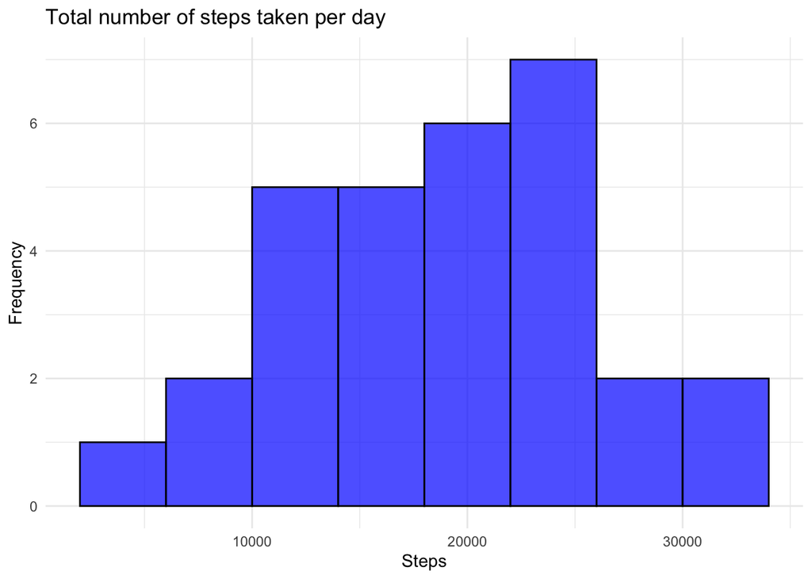

```r
total_steps_per_day <- aggregate(steps ~ day, data = activity, FUN = sum)

# Plot the histogram
ggplot(total_steps_per_day, aes(x = steps)) +
  geom_histogram(binwidth = 4000, fill = "blue", color = "black", alpha = 0.7) +
  labs(title = "Total number of steps taken per day", x = "Steps", y = "Frequency") +
  theme_minimal()
```

### b- the mean and median of the total number of steps taken per day

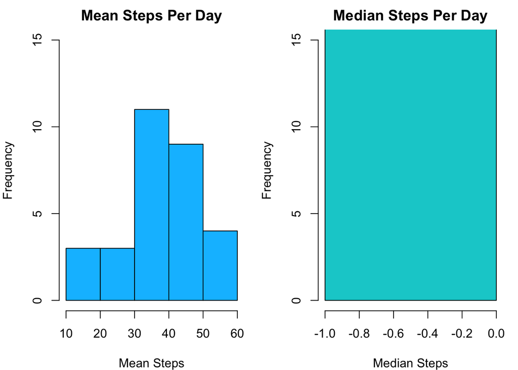

```r
mean_steps_per_day <- aggregate(steps ~ day, data = activity, FUN = mean)
median_steps_per_day <- aggregate(steps ~ day, data = activity, FUN = median)

par(mfrow = c(1, 2), mar = c(4, 4, 2, 1))

hist(mean_steps_per_day$steps, xlab = "Mean Steps", ylab = "Frequency", col = "deepskyblue", border = "black", main = "Mean Steps Per Day", breaks = 5, ylim = c(0, 15))
hist(median_steps_per_day$steps, xlab = "Median Steps", ylab = "Frequency", col = "darkturquoise", border = "black", main = "Median Steps Per Day", breaks = 5, ylim = c(0, 15))
```

```r
first_median_mean <- mean(median_steps_per_day$steps)
```

Wee see that the mean of the median is around **0** because there is huge number of days that the person didn’t actually take any step. We can see this here in the *top five number of steps* table

```r
no_step <- data.frame(sort(table(activity$steps), decreasing = TRUE)[1:5])
names(no_step) <- c("Number Of Steps", "Count")
no_step
```

```
##   Number Of Steps Count
## 1               0 11014
## 2               7    87
## 3               8    83
## 4              15    68
## 5              16    65
```

## 3- The average daily activity pattern

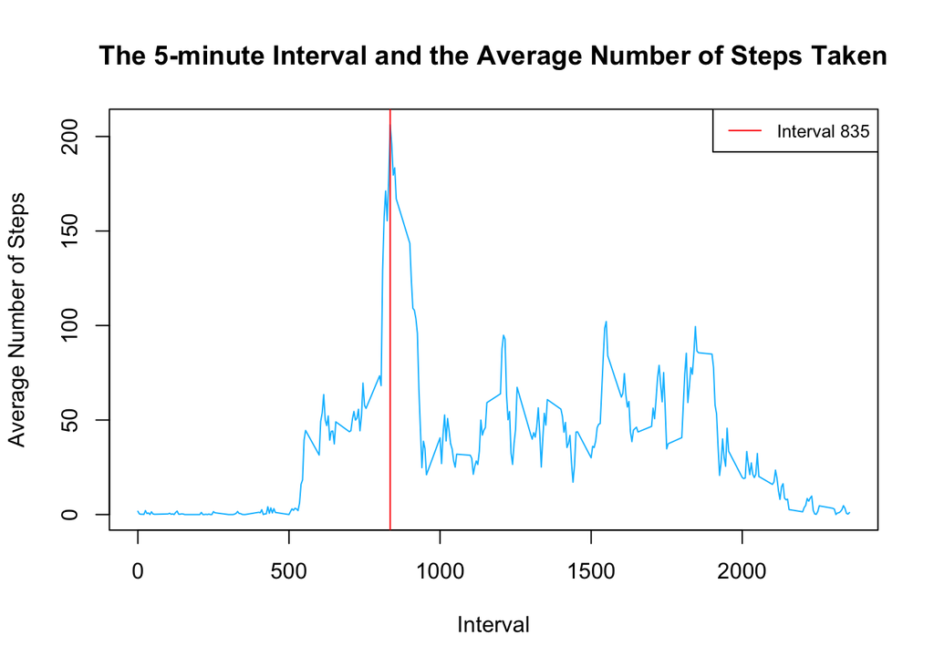

```r
interval_means <- activity %>%
  group_by(interval) %>%
  summarize(mean_steps = mean(steps, na.rm = TRUE))

interval_with_max_steps <- interval_means[which.max(interval_means$mean_steps),1]
with(interval_means, {
  plot(interval, mean_steps, type = "l", col = "deepskyblue",
       main = "The 5-minute Interval and the Average Number of Steps Taken",
       xlab = "Interval", ylab = "Average Number of Steps")
  # Add the vertical line
  abline(v = interval_with_max_steps, col = "red")
  legend("topright", legend = "Interval 835", col = "red", lty = 1, cex = 0.8)
})
```

So the 5-minute interval, on average across all the days in the activity dataset, contains the maximum number of steps is the **interval 835**

## 4- Imputing missing values

1. the total number of rows with (NAs)

```r
nrow_na <- activity %>% filter(is.na(steps)) %>% nrow()
```

- The total number of rows with missing values is **2304** which represent **13%** of the whole dataset
2. I will replace each missing value with the mean of the corresponding 5-minute interval from **interval_means**

```r
# Merge the interval means back into the original dataframe
activity_filled <- activity %>%
  left_join(interval_means, by = "interval") %>%
  mutate(steps = ifelse(is.na(steps), mean_steps, steps)) %>%
  select(-mean_steps)
head(activity_filled)
```

```
##       steps       date interval day
## 1 1.7169811 2012-10-01        0   1
## 2 0.3396226 2012-10-01        5   1
## 3 0.1320755 2012-10-01       10   1
## 4 0.1509434 2012-10-01       15   1
## 5 0.0754717 2012-10-01       20   1
## 6 2.0943396 2012-10-01       25   1
```

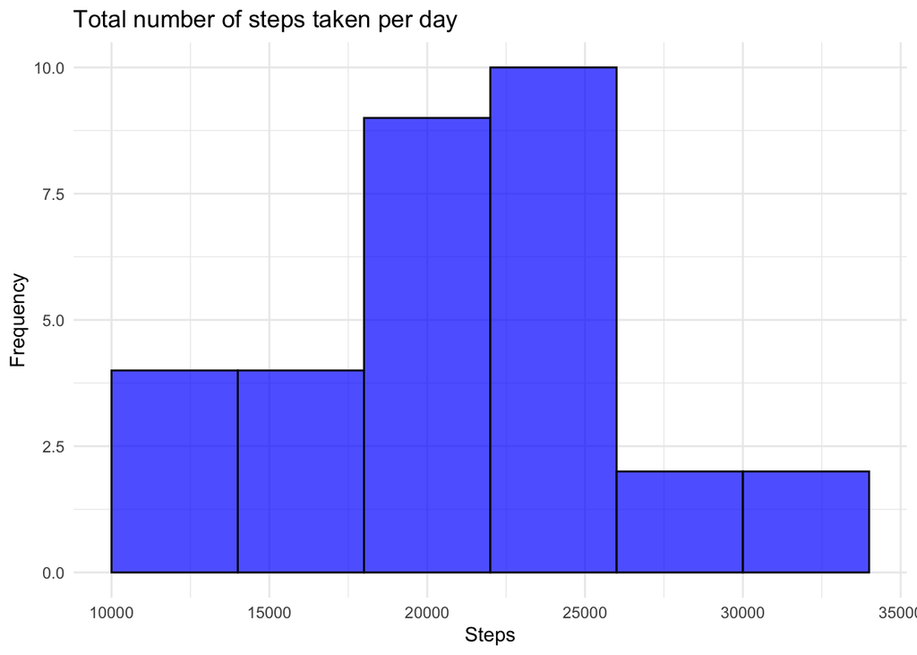

```r
total_steps_per_day <- aggregate(steps ~ day, data = activity_filled, FUN = sum)

# Plot the histogram
ggplot(total_steps_per_day, aes(x = steps)) +
  geom_histogram(binwidth = 4000, fill = "blue", color = "black", alpha = 0.7) +
  labs(title = "Total number of steps taken per day", x = "Steps", y = "Frequency") +
  theme_minimal()
```

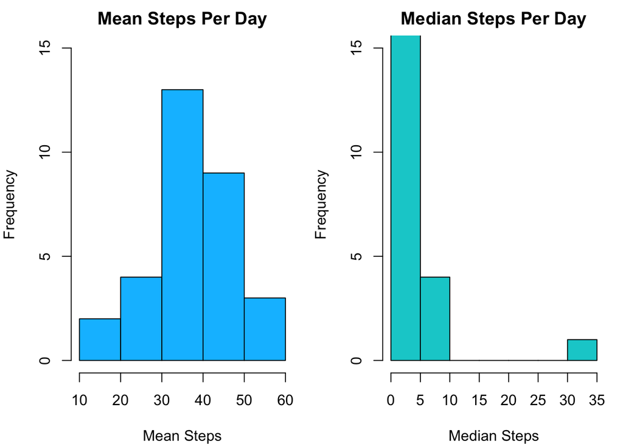

```r
# the mean and median of the total number of steps taken per day

mean_steps_per_day <- aggregate(steps ~ day, data = activity_filled, FUN = mean)
median_steps_per_day <- aggregate(steps ~ day, data = activity_filled, FUN = median)

par(mfrow = c(1, 2), mar = c(4, 4, 2, 1))

hist(mean_steps_per_day$steps, xlab = "Mean Steps", ylab = "Frequency", col = "deepskyblue", border = "black", main = "Mean Steps Per Day", breaks = 5, ylim = c(0, 15))
hist(median_steps_per_day$steps, xlab = "Median Steps", ylab = "Frequency", col = "darkturquoise", border = "black", main = "Median Steps Per Day", breaks = 5, ylim = c(0, 15))
```

```r
second_median_mean <- mean(median_steps_per_day$steps)
```

These values do differ from the estimates from the first part of the assignment. When can see in the mean histogram that values between **30-40 steps** increased a bit and also the mean of the median values is now around **2**.

## 5- Are there differences in activity patterns between weekdays and weekends?

### a- The new factor variable in the dataset with two levels – “weekday” and “weekend”

```r
activity_weekdays <- activity %>% mutate(day_name = weekdays(date, abbreviate = T))
unique(activity_weekdays$day_name)
```

```
## [1] "Mon" "Tue" "Wed" "Thu" "Fri" "Sat" "Sun"
```

```r
activity_weekdays <- activity_weekdays %>% mutate(work_chill = ifelse(!day_name %in% c("Sat", "Sun"), "weekday", "weekend"))
```

### b- The 5-minute Interval and the Average Number of Steps Taken averaged across all weekday days or weekend days

```r
interval_means <- activity_weekdays %>%
  group_by(interval, work_chill) %>%
  summarize(mean_steps = mean(steps, na.rm = TRUE))
```

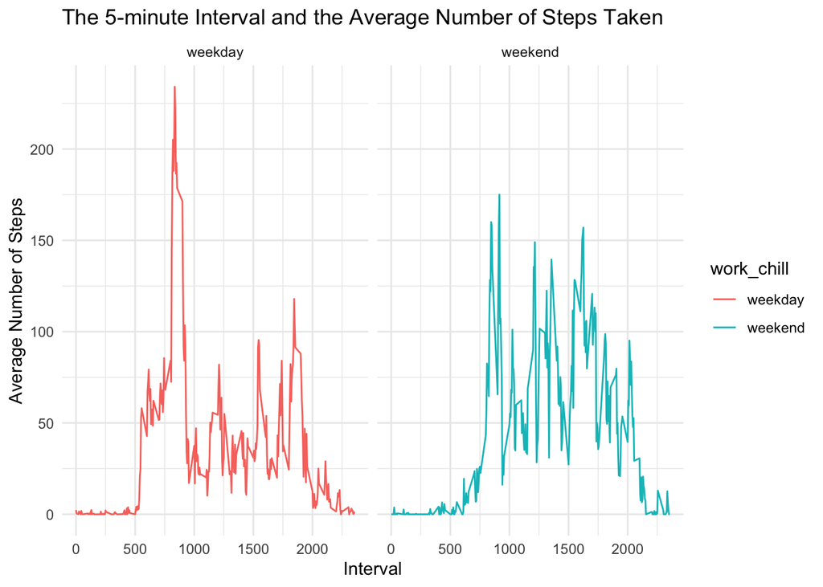

```r
ggplot(interval_means, aes(x = interval, y = mean_steps, color = work_chill)) +
  geom_line() +
  facet_wrap(~work_chill) +
  labs(title = "The 5-minute Interval and the Average Number of Steps Taken",
       x = "Interval", y = "Average Number of Steps") +
  theme_minimal()
```